# Support Vector Machines

Support vector machines (SVM) are another way of doing classification problems.

# 1 Optimal Separating Hyperplane

We try and find a plane that separates the classes in feature space.It approaches the classification problem as computer scientist would approach it. There’s no probability model as such, it really just looks for a hyperplane that separates the classes in a direct way. As this direct separation is not always possible, we use two methods: - We soften what we mean by “separates” and - We enrich and enlarge the feature space so that separation is possible.

## 1.1 What is a hyperplane?

A hyperplane in $p$ dimensions is a flat affine subspace of dimensions p-1. in $p$ = 2 dimensions a hyperplane is a line. If $\beta_0=0$ the hyperplane goes through the origin, otherwise not. The vector $\beta = (\beta_1,\beta_2,\dots, \beta_p)$ is called the normal vector and it points in a direction orthogonal to the surface of a hyperplane.

Imagine you have two classes plotted in a graph. You may be able to draw a line that separates one class from the other, but if you can do that, it is probable that you can draw other lines in different angles that also separates the two classes. What we want to find is that line that creates the biggest margin between the line and the points, so the line is at the maximum possible distance from points of the two classes.

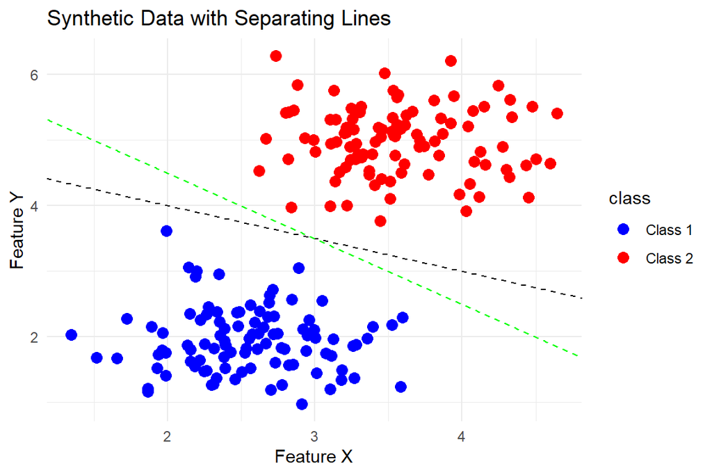

Often, the data is not separable by a line, typically when $n$ is bigger than $p$

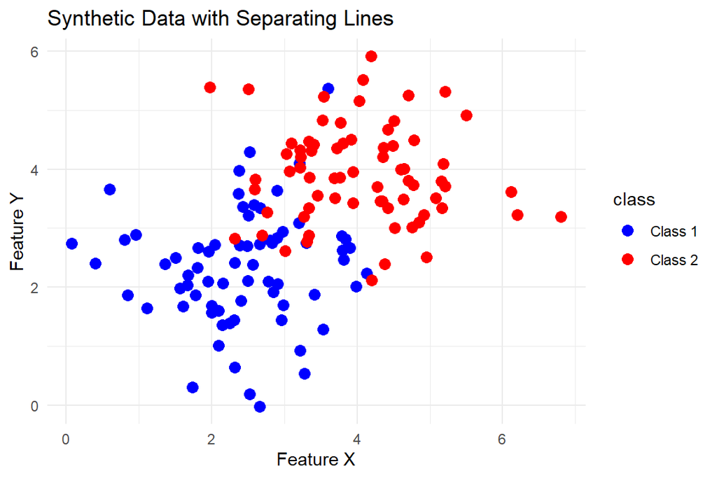

```r
set.seed(70)
n <- 70  # Number of points per class
class1 <- data.frame(x = rnorm(n, mean = 2.5, sd = 1),
  y = rnorm(n, mean = 2.5, sd = 1), class = "Class 1")
class2 <- data.frame(x = rnorm(n, mean = 4, sd = 1),
  y = rnorm(n, mean = 4, sd = 1), class = "Class 2")
data <- rbind(class1, class2)
# Plot the data with separating lines
ggplot(data, aes(x = x, y = y, color = class)) +
  geom_point(size = 3) +
  scale_color_manual(values = c("Class 1" = "blue", "Class 2" = "red")) +

  labs(title = "Synthetic Data with Separating Lines",
       x = "Feature X",
       y = "Feature Y") +
  theme_minimal()
```

when this is is the case we allow some points to trespass their margin, so we create what we call a *Soft margin*.

One important point of the support vector machine is that it is measuring euclidean distance and treats all units as the same, so the variables should be standardized.

# 2 Feature expansion

Another way of addressing the problem is to enlarge the space of features by including transformations, so instead of fitting a straight line, we can fit a polynomial e.g. $X_1^2$ hence we go from a $p$-dimensional space to a M>$p$ dimensional space.

# 3 Nonlinearities and Kernels

Polynomials, specially in high-dimensional spaces are not the ideal choice because they get wild rather fast. There is a more elegant and controlled way to introduce nonlinearities in support-vector classifiers through the use of *kernels*.

Math explained in video lectures and book. I skipped it here.

## 3.1 Support Vector Machine for more than two classes.

When we have more than two classes SVM takes two different approaches: OVA (one versus all): it compares each class against all others one by one, so it’s always comparing really two classes, but one of them is an aggregation of all the others. OVO (One versus One): it fits all pairwise classifiers $\binom{K}{2}$ and then classify a point $x$ to the class that wins the most pairwise competitions.

# 4 When to use?

When classes are nearly separable, SVM does better than logistic regression. So does Linear Discriminant Analysis (LDA) When not, Logistic Regression with ridge penalty and SVM are very similar. If you wish to estimate probabilities, logistic regression is the choice. For nonlinear boundaries, kernel SVMs are popular, can use kernels with logistic regression and Linear Discriminant Analysis as well, but computations are more expensive. With support vector machines we can solve high-dimensional problems, but it will use all the variables and won’t help us decide what features are important, that can be a drawback for the interpretation of the solution.

# 5 Practice

We use the `e1071` library in `R` to demonstrate the support vector classifier and the SVM. Another option is the `LiblineaR` library, which is useful for very large linear problems.

## 5.1 Support Vector Classifier

### 5.1.1 Linear support vector machine

The `e1071` library contains implementations for a number of statistical learning methods. In particular, the `svm()` function can be used to fit a support vector classifier when the argument `kernel = "linear"` is used. A `cost` argument allows us to specify the cost of a violation to the margin. When the `cost` argument is small, then the margins will be wide and many support vectors will be on the margin or will violate the margin. When the `cost` argument is large, then the margins will be narrow and there will be few support vectors on the margin or violating the margin.

We now use the `svm()` function to fit the support vector classifier for a given value of the `cost` parameter. Here we demonstrate the use of this function on a two-dimensional example so that we can plot the resulting decision boundary. We begin by generating the observations, which belong to two classes, and checking whether the classes are linearly separable.

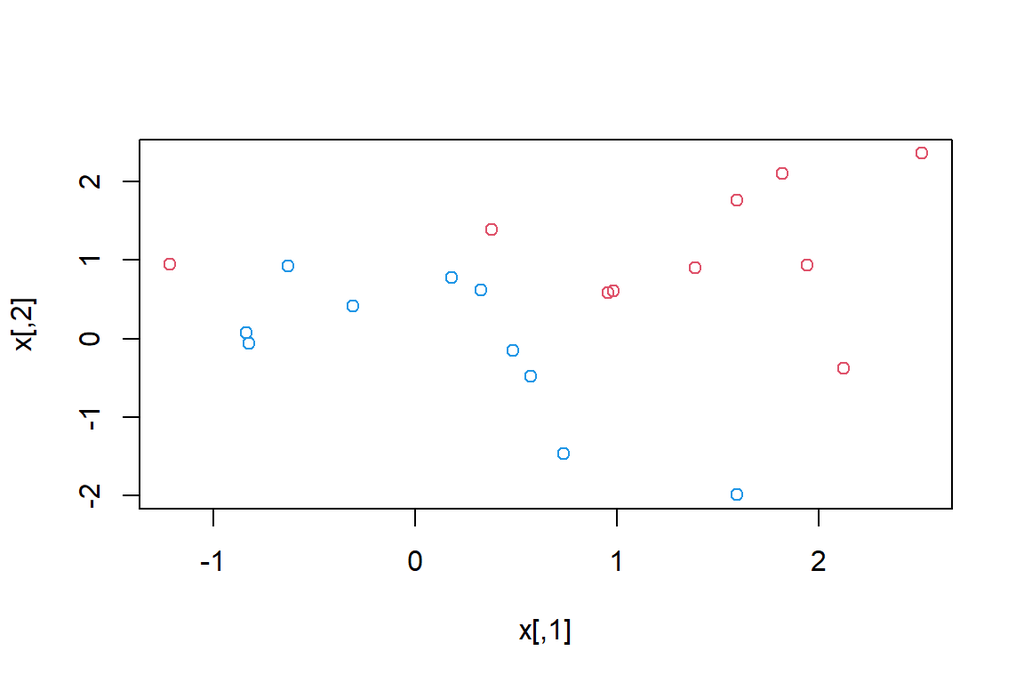

```r
set.seed(1)
x <- matrix(rnorm(20 * 2), ncol = 2)
y <- c(rep(-1, 10), rep(1, 10))
x[y == 1, ] <- x[y == 1, ] + 1
plot(x, col = (3 - y))
```

They are not sepparable. Next, we fit the support vector classifier. Note that in order for the `svm()` function to perform classification (as opposed to SVM-based regression), we must encode the response as a factor variable. We now create a data frame with the response coded as a factor.

```r
dat <- data.frame(x = x, y = as.factor(y))

svmfit <- svm(y ~ ., data = dat, kernel = "linear",
    cost = 10, scale = FALSE)
```

The argument `scale = FALSE` tells the `svm()` function not to scale each feature to have mean zero or standard deviation one; depending on the application, one might prefer to use `scale = TRUE`.

We can now plot the support vector classifier obtained:

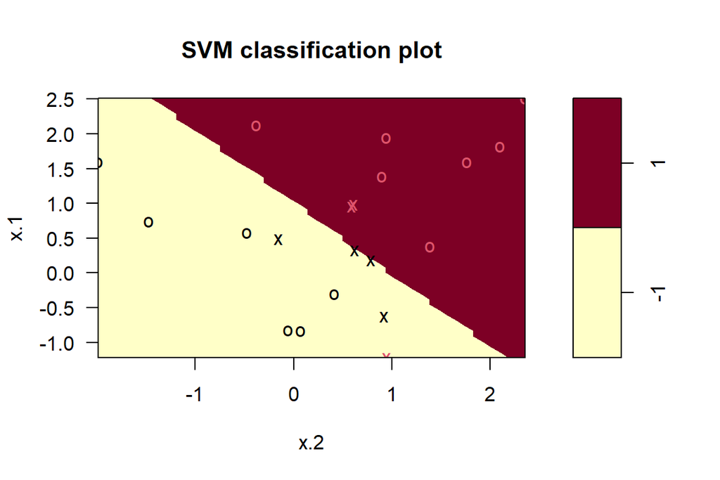

```r
plot(svmfit, dat)
```

Note that the two arguments to the SVM `plot()` function are the output of the call to `svm()`, as well as the data used in the call to `svm()`. The region of feature space that will be assigned to the $-1$ class is shown in light yellow, and the region that will be assigned to the $+1$ class is shown in red. The decision boundary between the two classes is linear (because we used the argument `kernel = "linear"`), though due to the way in which the plotting function is implemented in this library the decision boundary looks somewhat jagged in the plot. (Note that here the second feature is plotted on the $x$-axis and the first feature is plotted on the $y$-axis, in contrast to the behavior of the usual `plot()` function in `R`.) The *support vectors* are those data points that fall in the boundary or in the wrong side of the boundary The support vectors are plotted as crosses and the remaining observations are plotted as circles; we see here that there are seven support vectors. We can determine their identities as follows:

```r
svmfit$index
```

```
[1]  1  2  5  7 14 16 17
```

We can obtain some basic information about the support vector classifier fit using the `summary()` command:

```r
summary(svmfit)
```

```
Call:
svm(formula = y ~ ., data = dat, kernel = "linear", cost = 10, scale = FALSE)


Parameters:
   SVM-Type:  C-classification
 SVM-Kernel:  linear
       cost:  10

Number of Support Vectors:  7

 ( 4 3 )


Number of Classes:  2

Levels:
 -1 1
```

This tells us, for instance, that a linear kernel was used with `cost = 10`, and that there were seven support vectors, four in one class and three in the other.

We can also make our own plot: The first thing we will do is make a grid of values for X1 and X2. We will write a function to do that, in case we want to reuse it. It uses the handy function `expand.grid()`, and produces coordinates of `n*n` points on a lattice covering the domain of `x`. Having made the lattice, we make a prediction at each point on the laticce. We then plot the lattice, color-coded accordingly to the classification. Now we can see the decision boundary.

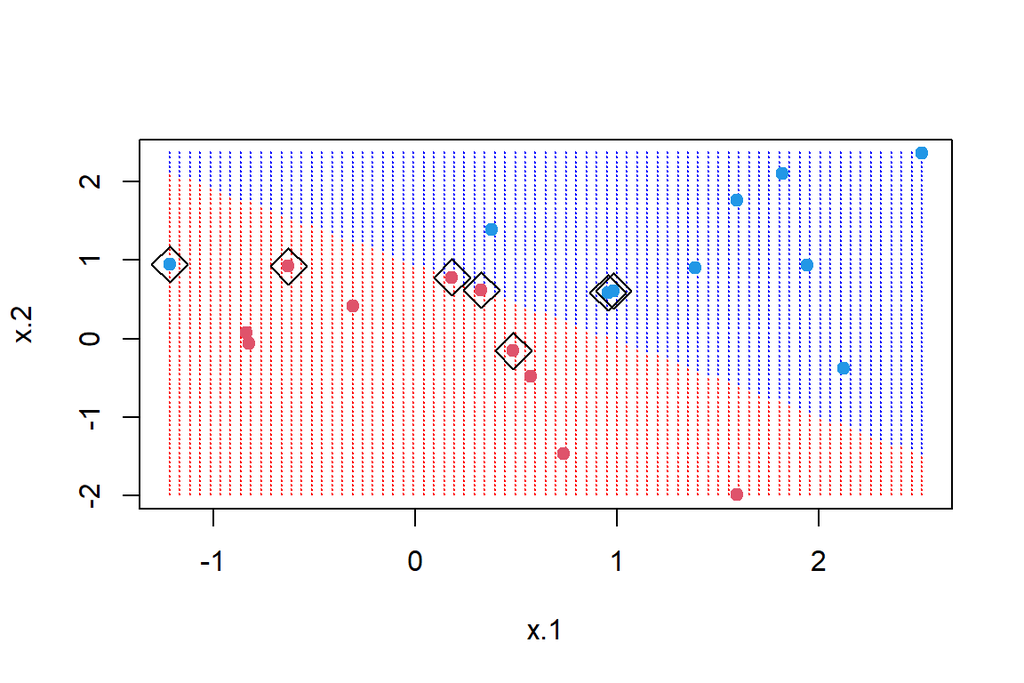

```r
make.grid= function(x, n=75){
  grange =apply(x,2,range) #get the range for each col
  x1=seq(from=grange[1,1],to=grange[2,1], length=n) #creates n points between the range of the first col
  x2=seq(from=grange[1,2],to=grange[2,2], length=n)#creates n points between the range of the second col
  expand.grid(x.1=x1,x.2=x2)
}
xgrid =make.grid(x)
ygrid = predict(svmfit,xgrid)
plot(xgrid,col=c("red","blue")[as.numeric(ygrid)],pch=20,cex=.2)
points(x,col=y+3, pch=19)
points(x[svmfit$index,], pch=5, cex=2) #support vector points
```

The `svm` function is not too friendly, in that we have to do some work to get back the linear coefficients, as described in the text. Probably the reason is that this only makes sense for linear kernels, and the function is more general. Here we will use a formula to extract the coefficients; for those interested in where this comes from, you can look in chapter 12 of the book *“Elements of Statistical Learning”*. We extract the linear coefficients, and then using simple algebra, we include the decision boundary and the two margins.

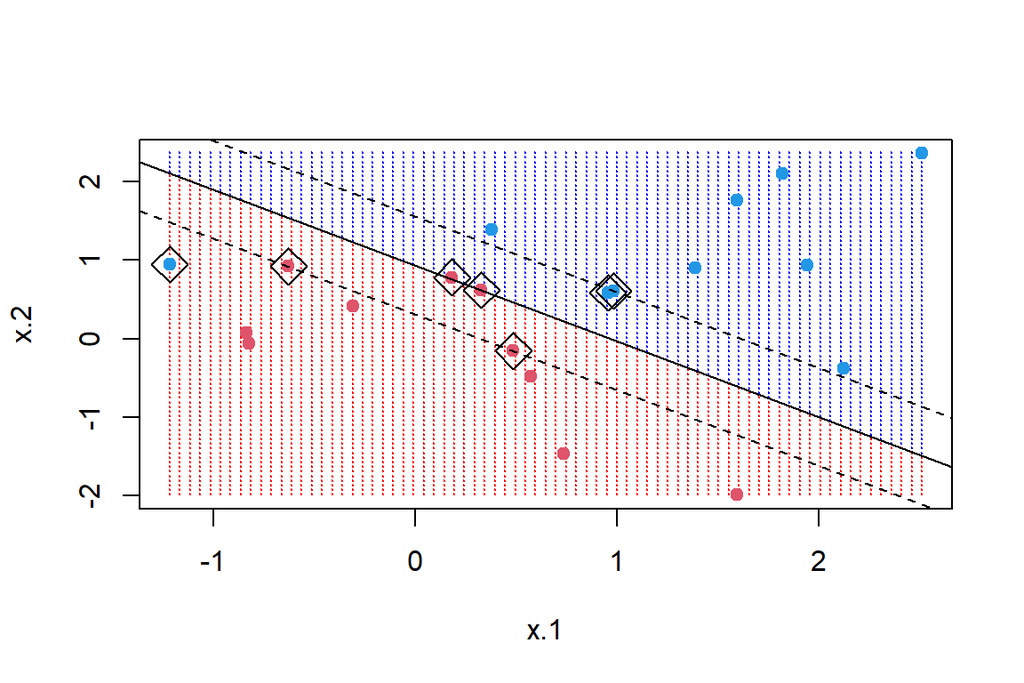

```r
beta=drop(t(svmfit$coefs)%*%x[svmfit$index,])
beta0 =svmfit$rho
plot(xgrid,col=c("red", "blue")[as.numeric(ygrid)],pch=20,cex=.2)
points(x,col=y+3,pch=19)
points(x[svmfit$index,], pch=5, cex=2)
abline(beta0/beta[2],-beta[1]/beta[2]) #decision boundary based on intersec and slope calculated with the coefficients
abline((beta0-1)/beta[2],-beta[1]/beta[2],lty=2) #margin
abline((beta0+1)/beta[2],-beta[1]/beta[2],lty=2) #margin
```

What if we instead used a smaller value of the cost parameter?

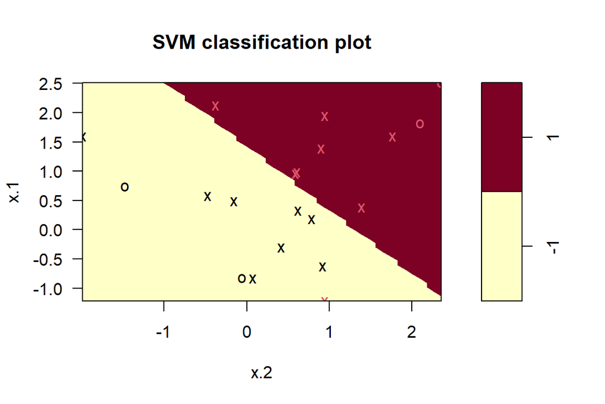

```r
svmfit <- svm(y ~ ., data = dat, kernel = "linear",
    cost = 0.1, scale = FALSE)
plot(svmfit, dat)
```

```r
svmfit$index
```

```
 [1]  1  2  3  4  5  7  9 10 12 13 14 15 16 17 18 20
```

Now that a smaller value of the cost parameter is being used, we obtain a larger number of support vectors, because the margin is now wider. Unfortunately, the `svm()` function does not explicitly output the coefficients of the linear decision boundary obtained when the support vector classifier is fit, nor does it output the width of the margin.

**Cross Validation**

The `e1071` library includes a built-in function, `tune()`, to perform cross-validation. By default, `tune()` performs ten-fold cross-validation on a set of models of interest. In order to use this function, we pass in relevant information about the set of models that are under consideration. The following command indicates that we want to compare SVMs with a linear kernel, using a range of values of the `cost` parameter.

```r
set.seed(1)
tune.out <- tune(svm, y ~ ., data = dat, kernel = "linear",
    ranges = list(cost = c(0.001, 0.01, 0.1, 1, 5, 10, 100)))
```

We can easily access the cross-validation errors for each of these models using the `summary()` command:

```r
summary(tune.out)
```

```
Parameter tuning of 'svm':

- sampling method: 10-fold cross validation

- best parameters:
 cost
  0.1

- best performance: 0.05

- Detailed performance results:
     cost error dispersion
1   0.001  0.55  0.4377975
2   0.010  0.55  0.4377975
3   0.100  0.05  0.1581139
4   1.000  0.15  0.2415229
5   5.000  0.15  0.2415229
6  10.000  0.15  0.2415229
7 100.000  0.15  0.2415229
```

We see that `cost = 0.1` results in the lowest cross-validation error rate. The `tune()` function stores the best model obtained, which can be accessed as follows:

```r
bestmod <- tune.out$best.model
summary(bestmod)
```

```
Call:
best.tune(METHOD = svm, train.x = y ~ ., data = dat, ranges = list(cost = c(0.001,
    0.01, 0.1, 1, 5, 10, 100)), kernel = "linear")


Parameters:
   SVM-Type:  C-classification
 SVM-Kernel:  linear
       cost:  0.1

Number of Support Vectors:  16

 ( 8 8 )


Number of Classes:  2

Levels:
 -1 1
```

The `predict()` function can be used to predict the class label on a set of test observations, at any given value of the cost parameter. We begin by generating a test data set.

```r
xtest <- matrix(rnorm(20 * 2), ncol = 2)
ytest <- sample(c(-1, 1), 20, rep = TRUE)
xtest[ytest == 1, ] <- xtest[ytest == 1, ] + 1
testdat <- data.frame(x = xtest, y = as.factor(ytest))
```

Now we predict the class labels of these test observations. Here we use the best model obtained through cross-validation in order to make predictions.

```r
ypred <- predict(bestmod, testdat)
table(predict = ypred, truth = testdat$y)
```

```
       truth
predict -1 1
     -1  9 1
     1   2 8
```

Thus, with this value of `cost`, 17 of the test observations are correctly classified. What if we had instead used `cost = 0.01`?

```r
svmfit <- svm(y ~ ., data = dat, kernel = "linear",
    cost = .01, scale = FALSE)
ypred <- predict(svmfit, testdat)
table(predict = ypred, truth = testdat$y)
```

```
       truth
predict -1  1
     -1 11  6
     1   0  3
```

In this case three additional observations are misclassified.

Now consider a situation in which the two classes are linearly separable. Then we can find a separating hyperplane using the `svm()` function. We first further separate the two classes in our simulated data so that they are linearly separable:

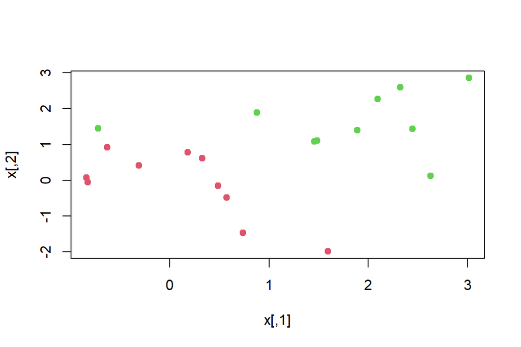

```r
x[y == 1, ] <- x[y == 1, ] + 0.5
plot(x, col = (y + 5) / 2, pch = 19)
```

Now the observations are just barely linearly separable. We fit the support vector classifier and plot the resulting hyperplane, using a very large value of `cost` so that no observations are misclassified.

```r
dat <- data.frame(x = x, y = as.factor(y))
svmfit <- svm(y ~ ., data = dat, kernel = "linear",
    cost = 1e5)
summary(svmfit)
```

```
Call:
svm(formula = y ~ ., data = dat, kernel = "linear", cost = 100000)


Parameters:
   SVM-Type:  C-classification
 SVM-Kernel:  linear
       cost:  100000

Number of Support Vectors:  3

 ( 1 2 )


Number of Classes:  2

Levels:
 -1 1
```

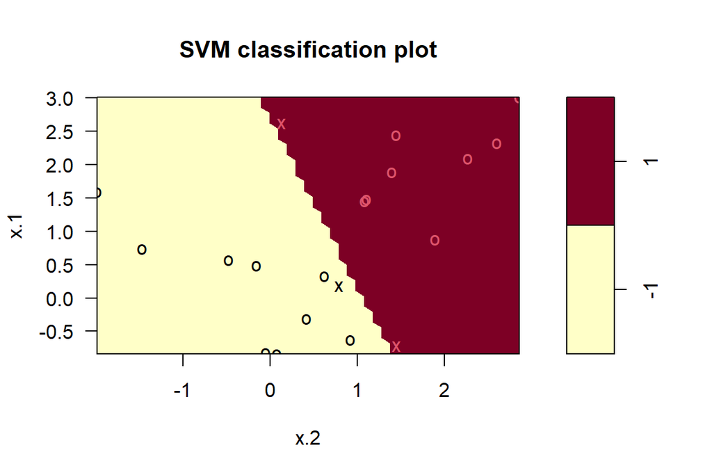

```r
plot(svmfit, dat)
```

No training errors were made and only three support vectors were used. However, we can see from the figure that the margin is very narrow (because the observations that are not support vectors, indicated as circles, are very close to the decision boundary). It seems likely that this model will perform poorly on test data. We now try a smaller value of `cost`:

```r
svmfit <- svm(y ~ ., data = dat, kernel = "linear", cost = 1)
summary(svmfit)
```

```
Call:
svm(formula = y ~ ., data = dat, kernel = "linear", cost = 1)


Parameters:
   SVM-Type:  C-classification
 SVM-Kernel:  linear
       cost:  1

Number of Support Vectors:  7

 ( 4 3 )


Number of Classes:  2

Levels:
 -1 1
```

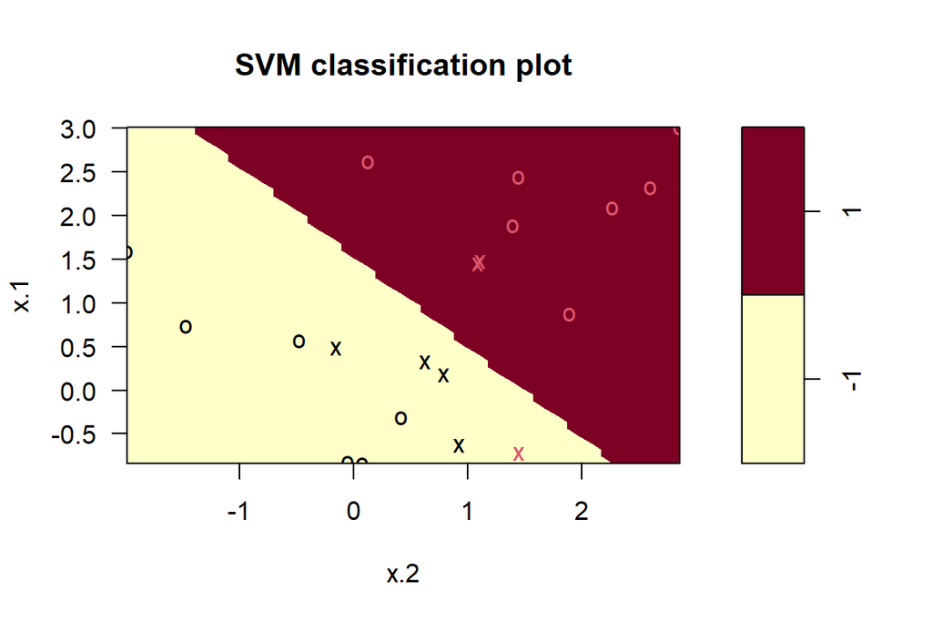

```r
plot(svmfit, dat)
```

Using `cost = 1`, we misclassify a training observation, but we also obtain a much wider margin and make use of seven support vectors. It seems likely that this model will perform better on test data than the model with `cost = 1e5`.

### 5.1.2 Non Linear SVM

In order to fit an SVM using a non-linear kernel, we once again use the `svm()` function. However, now we use a different value of the parameter `kernel`. To fit an SVM with a polynomial kernel we use `kernel = "polynomial"`, and to fit an SVM with a radial kernel we use `kernel = "radial"`. In the former case we also use the `degree` argument to specify a degree for the polynomial kernel (this is $d$ in (9.22)), and in the latter case we use `gamma` to specify a value of $\gamma$ for the radial basis kernel.

We first generate some data with a non-linear class boundary, as follows:

```r
set.seed(1)
x <- matrix(rnorm(200 * 2), ncol = 2)
x[1:100, ] <- x[1:100, ] + 2
x[101:150, ] <- x[101:150, ] - 2
y <- c(rep(1, 150), rep(2, 50))
dat <- data.frame(x = x, y = as.factor(y))
```

Plotting the data makes it clear that the class boundary is indeed non-linear:

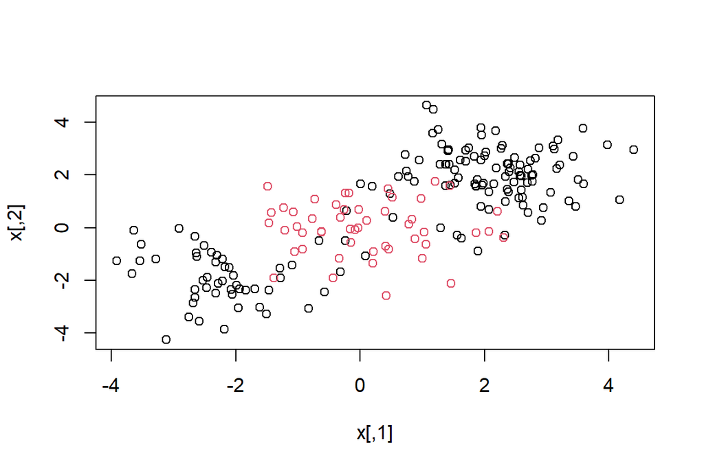

```r
plot(x, col = y)
```

The data is randomly split into training and testing groups. We then fit the training data using the `svm()` function with a radial kernel and $\gamma=1$:

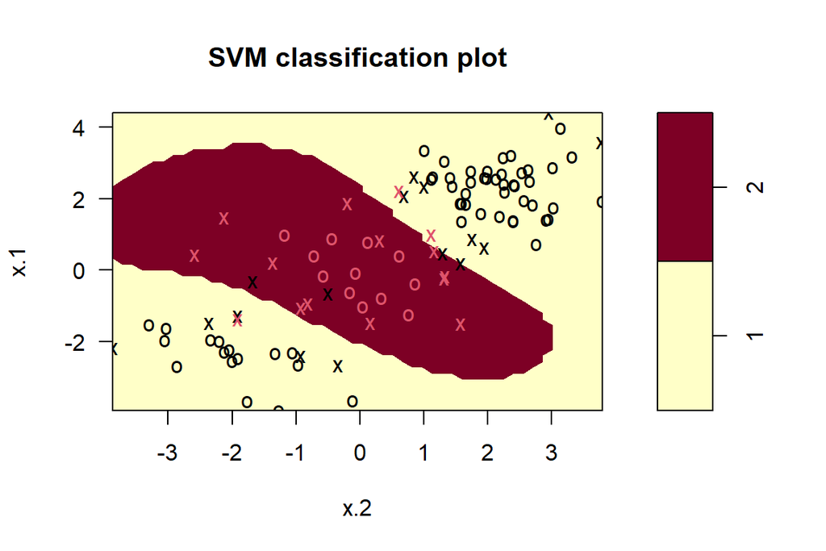

```r
train <- sample(200, 100)
svmfit <- svm(y ~ ., data = dat[train, ], kernel = "radial",
    gamma = 1, cost = 1)
plot(svmfit, dat[train, ])
```

The plot shows that the resulting SVM has a decidedly non-linear boundary. The `summary()` function can be used to obtain some information about the SVM fit:

```r
summary(svmfit)
```

```
Call:
svm(formula = y ~ ., data = dat[train, ], kernel = "radial", gamma = 1,
    cost = 1)


Parameters:
   SVM-Type:  C-classification
 SVM-Kernel:  radial
       cost:  1

Number of Support Vectors:  31

 ( 16 15 )


Number of Classes:  2

Levels:
 1 2
```

We can see from the figure that there are a fair number of training errors in this SVM fit. If we increase the value of `cost`, we can reduce the number of training errors. However, this comes at the price of a more irregular decision boundary that seems to be at risk of overfitting the data.

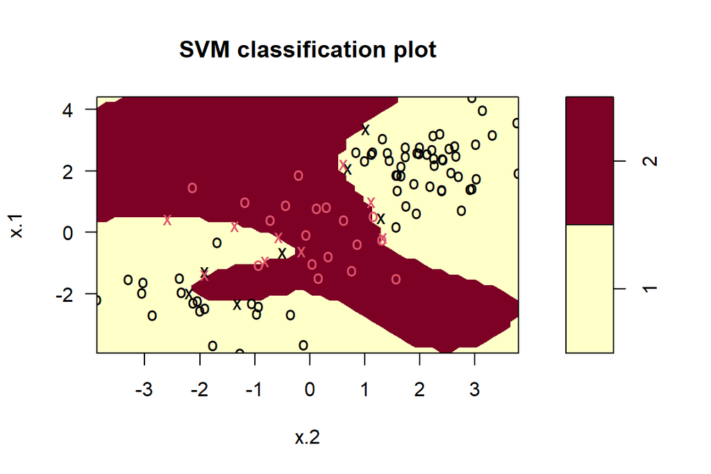

```r
svmfit <- svm(y ~ ., data = dat[train, ], kernel = "radial",
    gamma = 1, cost = 1e5)
plot(svmfit, dat[train, ])
```

We can perform cross-validation using `tune()` to select the best choice of $\gamma$ and `cost` for an SVM with a radial kernel:

```r
set.seed(1)
tune.out <- tune(svm, y ~ ., data = dat[train, ],
    kernel = "radial",
    ranges = list(
      cost = c(0.1, 1, 10, 100, 1000),
      gamma = c(0.5, 1, 2, 3, 4)
    )
  )
summary(tune.out)
```

```
Parameter tuning of 'svm':

- sampling method: 10-fold cross validation

- best parameters:
 cost gamma
    1   0.5

- best performance: 0.07

- Detailed performance results:
     cost gamma error dispersion
1     0.1   0.5  0.26 0.15776213
2     1.0   0.5  0.07 0.08232726
3    10.0   0.5  0.07 0.08232726
```

[output cut: 22 more lines]

Therefore, the best choice of parameters involves `cost = 1` and `gamma = 0.5`. We can view the test set predictions for this model by applying the `predict()` function to the data. Notice that to do this we subset the dataframe `dat` using `-train` as an index set.

```r
table(
    true = dat[-train, "y"],
    pred = predict(
      tune.out$best.model, newdata = dat[-train, ]
      )
    )
```

```
    pred
true  1  2
   1 67 10
   2  2 21
```

$12 \%$ of test observations are misclassified by this SVM.

Non linear SVM classification example

We use the ESL.mixture data from *Elements of Statistical Learning* [book](https://hastie.su.domains/ElemStatLearn/)

```r
load("data/ESL.mixture.rda")
names(ESL.mixture)
```

```
[1] "x"        "y"        "xnew"     "prob"     "marginal" "px1"      "px2"
[8] "means"
```

The data is two dimensional.

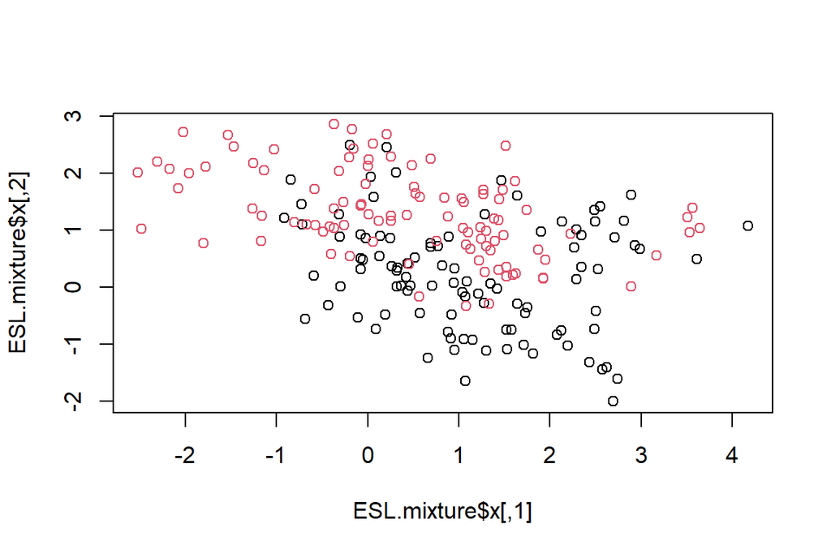

```r
plot(ESL.mixture$x, col=ESL.mixture$y+1)
```

```r
dat =data.frame(y=factor(ESL.mixture$y), ESL.mixture$x)
fit=svm(factor(y) ~., data=dat, scale=F,kernell ="radial", cost=5)
```

Now we are going to create a grid, as before, and make predictions on the grid. These data have the grid points for each variable included on the data object loaded, so we don’t have to create the grid directly, we can just expand it

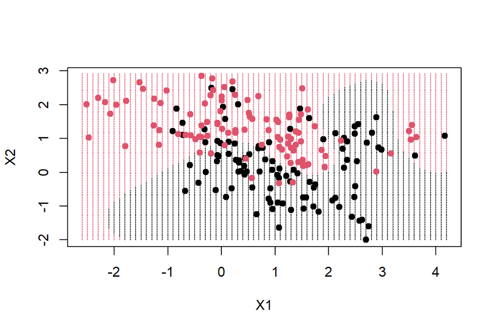

```r
xgrid =expand.grid(X1 =ESL.mixture$px1, X2=ESL.mixture$px2)
ygrid = predict(fit, xgrid)
plot(xgrid,col=as.numeric(ygrid),pch=20,cex=.2)
points(ESL.mixture$x,col=ESL.mixture$y+1, pch=19,cex=1)
```

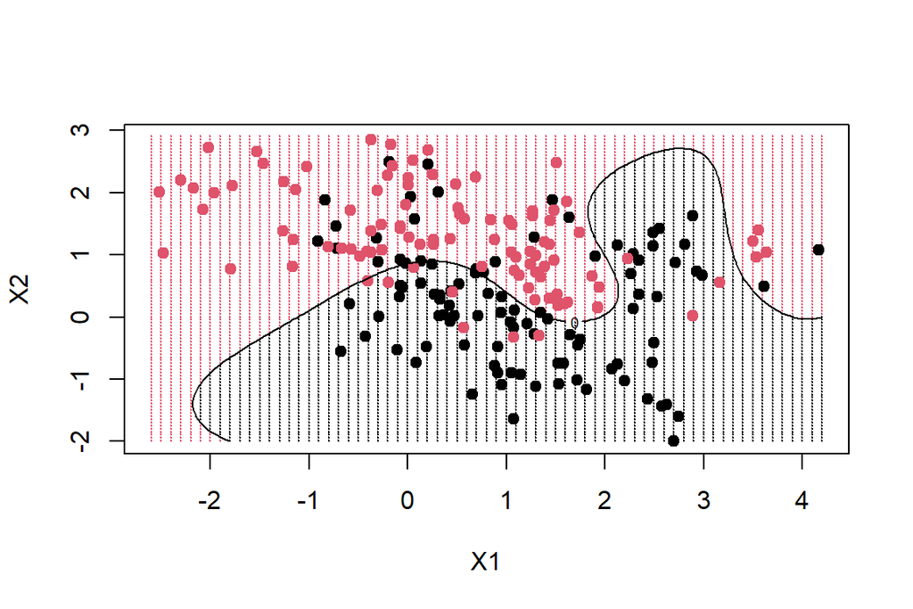

```r
func= predict(fit, xgrid,decision.values=T)
func=attributes(func)$decision
xgrid =expand.grid(X1 =ESL.mixture$px1, X2=ESL.mixture$px2)
ygrid = predict(fit,xgrid)
plot(xgrid,col=as.numeric(ygrid), pch=20, cex=.2)
points(ESL.mixture$x,col=ESL.mixture$y+1, pch=19,cex=1)

contour(ESL.mixture$px1,ESL.mixture$px2, matrix(func,69,99), level=0, add=T)
```

## 5.2 ROC Curves

The `ROCR` package can be used to produce ROC curves. We first write a short function to plot an ROC curve given a vector containing a numerical score for each observation, `pred`, and a vector containing the class label for each observation, `truth`.

```r
rocplot <- function(pred, truth, ...) {
  predob <- prediction(pred, truth)
  perf <- performance(predob, "tpr", "fpr")
  plot(perf, ...)
}
```

SVMs and support vector classifiers output class labels for each observation. However, it is also possible to obtain *fitted values* for each observation, which are the numerical scores used to obtain the class labels. For instance, in the case of a support vector classifier, the fitted value for an observation $X= (X_1, X_2, \ldots, X_p)^T$ takes the form $\hat{\beta}_0 + \hat{\beta}_1 X_1 + \hat{\beta}_2 X_2 + \cdots + \hat{\beta}_p X_p$. In essence, the sign of the fitted value determines on which side of the decision boundary the observation lies. Therefore, the relationship between the fitted value and the class prediction for a given observation is simple: if the fitted value exceeds zero then the observation is assigned to one class, and if it is less than zero then it is assigned to the other. In order to obtain the fitted values for a given SVM model fit, we use `decision.values = TRUE` when fitting `svm()`. Then the `predict()` function will output the fitted values.

```r
svmfit.opt <- svm(y ~ ., data = dat[train, ],
    kernel = "radial", gamma = 2, cost = 1,
    decision.values = T)
fitted <- attributes(
    predict(svmfit.opt, dat[train, ], decision.values = TRUE)
  )$decision.values
```

Now we can produce the ROC plot. Note we use the negative of the fitted values so that negative values correspond to class 1 and positive values to class 2.

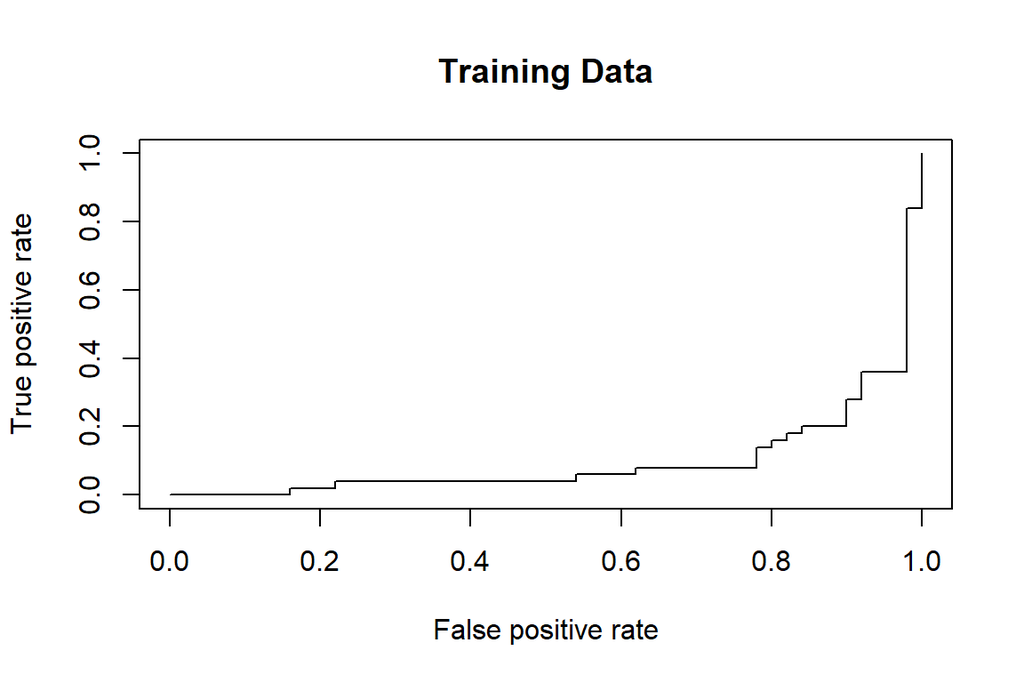

```r
rocplot(-fitted, dat[train, "y"], main = "Training Data")
```

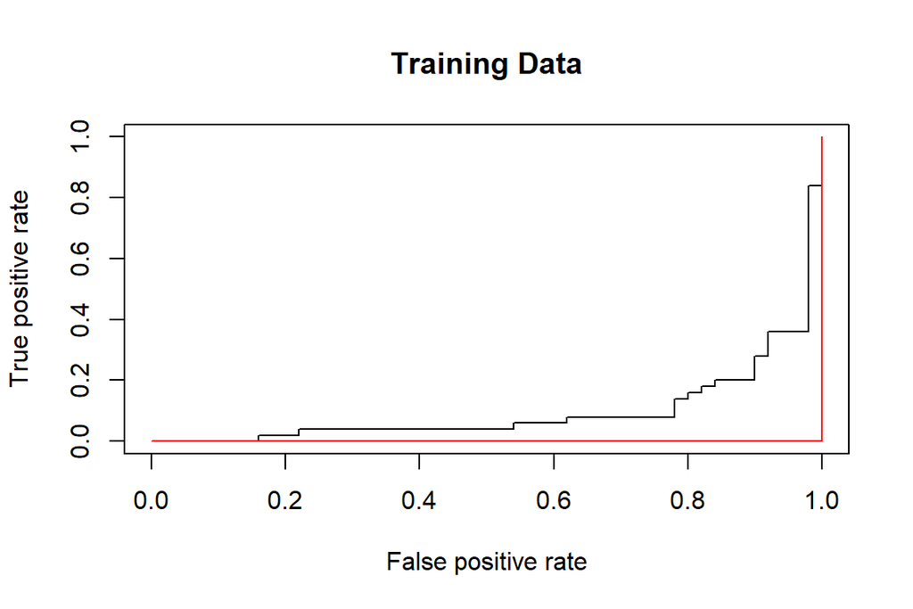

```r
rocplot(-fitted, dat[train, "y"], main = "Training Data")
svmfit.flex <- svm(y ~ ., data = dat[train, ],
    kernel = "radial", gamma = 50, cost = 1,
    decision.values = T)
fitted <- attributes(
    predict(svmfit.flex, dat[train, ], decision.values = T)
  )$decision.values
rocplot(-fitted, dat[train, "y"], add = T, col = "red")
```

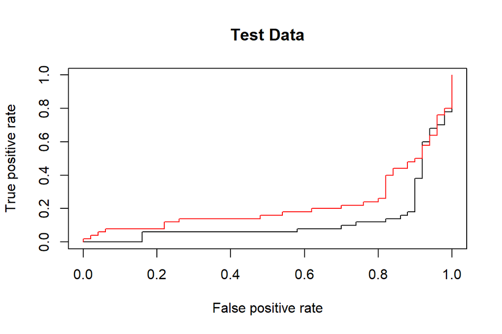

```r
fitted <- attributes(
    predict(svmfit.opt, dat[-train, ], decision.values = T)
  )$decision.values
rocplot(-fitted, dat[-train, "y"], main = "Test Data")
fitted <- attributes(
    predict(svmfit.flex, dat[-train, ], decision.values = T)
  )$decision.values
rocplot(-fitted, dat[-train, "y"], add = T, col = "red")
```

## 5.3 SVM with Multiple Classes

If the response is a factor containing more than two levels, then the `svm()` function will perform multi-class classification using the one-versus-one approach. We explore that setting here by generating a third class of observations.

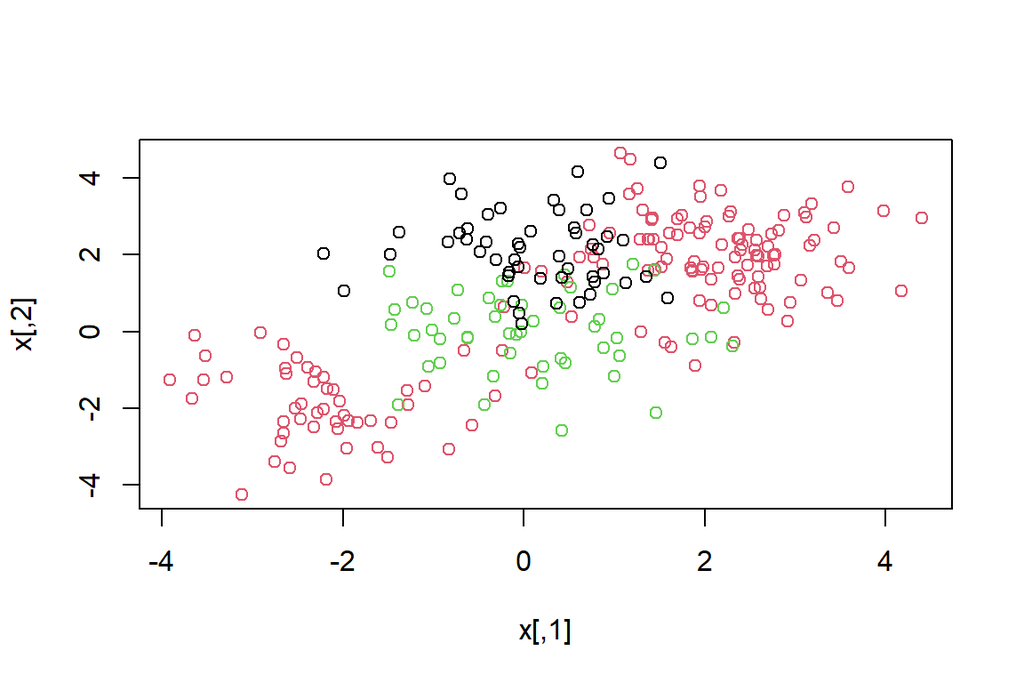

```r
set.seed(1)
x <- rbind(x, matrix(rnorm(50 * 2), ncol = 2))
y <- c(y, rep(0, 50))
x[y == 0, 2] <- x[y == 0, 2] + 2
dat <- data.frame(x = x, y = as.factor(y))
par(mfrow = c(1, 1))
plot(x, col = (y + 1))
```

We now fit an SVM to the data:

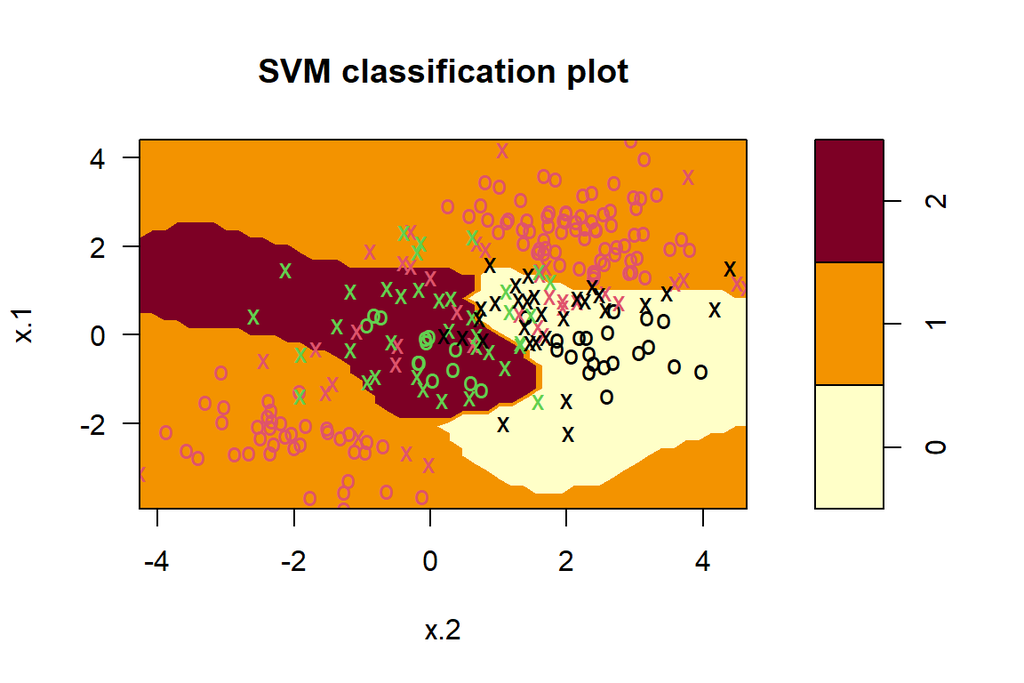

```r
svmfit <- svm(y ~ ., data = dat, kernel = "radial",
    cost = 10, gamma = 1)
plot(svmfit, dat)
```

## 5.4 Support vector regression

The `e1071` library can also be used to perform support vector regression, if the response vector that is passed in to `svm()` is numerical rather than a factor.

## 5.5 Application to Gene Expression Data

We now examine the `Khan` data set, which consists of a number of tissue samples corresponding to four distinct types of small round blue cell tumors. For each tissue sample, gene expression measurements are available. The data set consists of training data, `xtrain` and `ytrain`, and testing data, `xtest` and `ytest`.

We examine the dimension of the data:

```r
library(ISLR2)
names(Khan)
```

```
[1] "xtrain" "xtest"  "ytrain" "ytest"
```

```r
dim(Khan$xtrain)
```

```
[1]   63 2308
```

```r
dim(Khan$xtest)
```

```
[1]   20 2308
```

```r
length(Khan$ytrain)
```

```
[1] 63
```

```r
length(Khan$ytest)
```

```
[1] 20
```

This data set consists of expression measurements for $2{,}308$ genes. The training and test sets consist of $63$ and $20$ observations respectively.

```r
table(Khan$ytrain)
```

```
 1  2  3  4
 8 23 12 20
```

```r
table(Khan$ytest)
```

```
1 2 3 4
3 6 6 5
```

We will use a support vector approach to predict cancer subtype using gene expression measurements. In this data set, there are a very large number of features relative to the number of observations. This suggests that we should use a linear kernel, because the additional flexibility that will result from using a polynomial or radial kernel is unnecessary.

```r
dat <- data.frame(
    x = Khan$xtrain,
    y = as.factor(Khan$ytrain)
  )
out <- svm(y ~ ., data = dat, kernel = "linear",
    cost = 10)
summary(out)
```

```
Call:
svm(formula = y ~ ., data = dat, kernel = "linear", cost = 10)


Parameters:
   SVM-Type:  C-classification
 SVM-Kernel:  linear
       cost:  10

Number of Support Vectors:  58

 ( 20 20 11 7 )


Number of Classes:  4

Levels:
 1 2 3 4
```

```r
table(out$fitted, dat$y)
```

```
     1  2  3  4
  1  8  0  0  0
  2  0 23  0  0
  3  0  0 12  0
  4  0  0  0 20
```

We see that there are *no* training errors. In fact, this is not surprising, because the large number of variables relative to the number of observations implies that it is easy to find hyperplanes that fully separate the classes. We are most interested not in the support vector classifier’s performance on the training observations, but rather its performance on the test observations.

```r
dat.te <- data.frame(
    x = Khan$xtest,
    y = as.factor(Khan$ytest))
pred.te <- predict(out, newdata = dat.te)
table(pred.te, dat.te$y)
```

```
pred.te 1 2 3 4
      1 3 0 0 0
      2 0 6 2 0
      3 0 0 4 0
      4 0 0 0 5
```

We see that using `cost = 10` yields two test set errors on this data.